# Project Python Foundations: FoodHub Data Analysis

**Marks: 60**

### Context

The number of restaurants in New York is increasing day by day. Lots of students and busy professionals rely on those restaurants due to their hectic lifestyles. Online food delivery service is a great option for them. It provides them with good food from their favorite restaurants. A food aggregator company FoodHub offers access to multiple restaurants through a single smartphone app.

The app allows the restaurants to receive a direct online order from a customer. The app assigns a delivery person from the company to pick up the order after it is confirmed by the restaurant. The delivery person then uses the map to reach the restaurant and waits for the food package. Once the food package is handed over to the delivery person, he/she confirms the pick-up in the app and travels to the customer's location to deliver the food. The delivery person confirms the drop-off in the app after delivering the food package to the customer. The customer can rate the order in the app. The food aggregator earns money by collecting a fixed margin of the delivery order from the restaurants.

### Objective

The food aggregator company has stored the data of the different orders made by the registered customers in their online portal. They want to analyze the data to get a fair idea about the demand of different restaurants which will help them in enhancing their customer experience. Suppose you are hired as a Data Scientist in this company and the Data Science team has shared some of the key questions that need to be answered. Perform the data analysis to find answers to these questions that will help the company to improve the business.

### Data Description

The data contains the different data related to a food order. The detailed data dictionary is given below.

### Data Dictionary

- order_id: Unique ID of the order
- customer_id: ID of the customer who ordered the food
- restaurant_name: Name of the restaurant
- cuisine_type: Cuisine ordered by the customer
- cost: Cost of the order
- day_of_the_week: Indicates whether the order is placed on a weekday or weekend (The weekday is from Monday to Friday and the weekend is Saturday and Sunday)
- rating: Rating given by the customer out of 5
- food_preparation_time: Time (in minutes) taken by the restaurant to prepare the food. This is calculated by taking the difference between the timestamps of the restaurant's order confirmation and the delivery person's pick-up confirmation.
- delivery_time: Time (in minutes) taken by the delivery person to deliver the food package. This is calculated by taking the difference between the timestamps of the delivery person's pick-up confirmation and drop-off information

### Let us start by importing the required libraries

```python
# import libraries for data manipulation
import numpy as np
import pandas as pd

# import libraries for data visualization
import matplotlib.pyplot as plt
import seaborn as sns
```

### Understanding the structure of the data

```python
# uncomment and run the following lines for Google Colab
from google.colab import drive
drive.mount('/content/drive')
```

```python
# read the data
df = pd.read_csv('foodhub_order.csv')
# returns the first 5 rows
df
```

|  | order_id | customer_id | restaurant_name | cuisine_type | cost_of_the_order | day_of_the_week | rating | food_preparation_time | delivery_time |
| --- | --- | --- | --- | --- | --- | --- | --- | --- | --- |
| 0 | 1477147 | 337525 | Hangawi | Korean | 30.75 | Weekend | Not given | 25 | 20 |
| 1 | 1477685 | 358141 | Blue Ribbon Sushi Izakaya | Japanese | 12.08 | Weekend | Not given | 25 | 23 |
| 2 | 1477070 | 66393 | Cafe Habana | Mexican | 12.23 | Weekday | 5 | 23 | 28 |
| 3 | 1477334 | 106968 | Blue Ribbon Fried Chicken | American | 29.20 | Weekend | 3 | 25 | 15 |
| 4 | 1478249 | 76942 | Dirty Bird to Go | American | 11.59 | Weekday | 4 | 25 | 24 |
| ... | ... | ... | ... | ... | ... | ... | ... | ... | ... |
| 1893 | 1476701 | 292602 | Chipotle Mexican Grill $1.99 Delivery | Mexican | 22.31 | Weekend | 5 | 31 | 17 |
| 1894 | 1477421 | 397537 | The Smile | American | 12.18 | Weekend | 5 | 31 | 19 |
| 1895 | 1477819 | 35309 | Blue Ribbon Sushi | Japanese | 25.22 | Weekday | Not given | 31 | 24 |
| 1896 | 1477513 | 64151 | Jack's Wife Freda | Mediterranean | 12.18 | Weekday | 5 | 23 | 31 |
| 1897 | 1478056 | 120353 | Blue Ribbon Sushi | Japanese | 19.45 | Weekend | Not given | 28 | 24 |

1898 rows × 9 columns

#### Observations:

The DataFrame has 9 columns as mentioned in the Data Dictionary. Data in each row corresponds to the order placed by a customer.

### **Question 1:** How many rows and columns are present in the data? [0.5 mark]

```python
df.shape # -> displays (rows, cols)
```

```
(1898, 9)
```

#### Observations: There are 1898 rows and 9 columns.

### **Question 2:** What are the datatypes of the different columns in the dataset? (The info() function can be used) [0.5 mark]

```python
df.info()
```

```
<class 'pandas.core.frame.DataFrame'>
RangeIndex: 1898 entries, 0 to 1897
Data columns (total 9 columns):
 #   Column                 Non-Null Count  Dtype
---  ------                 --------------  -----
 0   order_id               1898 non-null   int64
 1   customer_id            1898 non-null   int64
 2   restaurant_name        1898 non-null   object
 3   cuisine_type           1898 non-null   object
 4   cost_of_the_order      1898 non-null   float64
 5   day_of_the_week        1898 non-null   object
 6   rating                 1898 non-null   object
 7   food_preparation_time  1898 non-null   int64
 8   delivery_time          1898 non-null   int64
dtypes: float64(1), int64(4), object(4)
memory usage: 133.6+ KB
```

#### Observations:

- "order_id", "custemer_id", "food_preparation_time", and "delivery_time" are all integers
- "cost_of_the_order" is a float (in dollars)
- "restaurant_name" and "cuisine_type" are strings
- "day_of_the_week" is categorical, with "weekday" and "weekend" as possible values
- "rating" is supposed to be an integer 1-5, except they're stored as strings alongside some that are recorded as "Not given". Cleanup target.

### **Question 3:** Are there any missing values in the data? If yes, treat them using an appropriate method. [1 mark]

```python
#First check directly for NaN or null values
df.isnull().sum()
```

```
order_id                 0
customer_id              0
restaurant_name          0
cuisine_type             0
cost_of_the_order        0
day_of_the_week          0
rating                   0
food_preparation_time    0
delivery_time            0
dtype: int64
```

#### Observations:

There are 0 direct missing values, but that's not conclusive since there are ways for values to be missing other than NaN.

```python
#Check the unique values of each column
for col in df:
  print(col)
  print(df[col].unique())
  print()
```

[output not shown]

[output cut: 45 more lines]

```
 19.74 18.04 31.67  5.05  7.03 14.8  12.17  7.28 15.13  7.81 16.74  9.31
 21.25 31.87 19.02 34.19  5.53 22.46 29.73 10.43 19.5   4.9  15.37  7.67
  7.91 13.53 33.37 19.6  13.48 20.71 20.61  7.66 10.86  7.95 20.86 29.59]

day_of_the_week
['Weekend' 'Weekday']

rating
['Not given' '5' '3' '4']

food_preparation_time
[25 23 20 28 33 21 29 34 24 30 35 32 31 27 22 26]

delivery_time
[20 23 28 15 24 21 30 26 22 17 25 16 29 27 18 31 32 19 33]
```

Observations:

Everything looks good here except for "ratings". It should be integers 1-5, but except for the "Not given" in the ratings. How many of those are there?

```python
df['rating'].value_counts()
```

```
Not given    736
5            588
4            386
3            188
Name: rating, dtype: int64
```

We have 736 rows with a missing rating, the most common "rating". The easiest treatment would be to replace those with the mode (5), since most people just give 5 stars unless they have a complaint. But we could lose a lot of information that way since what if the lack of rating given is related to the quality of the service?

My next idea is to replace the non-rating with the average rating given to that specific restaurant. This way, when we look at restaurant ratings later, their average ratings won't change relative to each other.

```python
#First replace the string numbers in 'ratings' with python integers and NaN elsewhere
df['rating'] = pd.to_numeric(df['rating'], errors='coerce')

#Get grouping of average rating by restaurant
grouped_df = df.groupby('restaurant_name')
avg_ratings = grouped_df['rating'].mean()

#Apply function to each row to replace NaN value with restaurant's average, or else leave it alone
df['rating'] = df.apply(lambda row: avg_ratings[row['restaurant_name']] if pd.isna(row['rating']) else row['rating'], axis=1)
```

```python
# The previous treatment was mostly successful, but there were still some NaNs for restaurants that never happened to receive a rating.
# I'm okay with just saying "no news is good news" here and put 5s for these few. If they had a complaint, they would have made it.
df['rating'] = df['rating'].fillna(5.0)
```

### **Question 4:** Check the statistical summary of the data. What is the minimum, average, and maximum time it takes for food to be prepared once an order is placed? [2 marks]

```python
df.describe()
```

|  | order_id | customer_id | cost_of_the_order | rating | food_preparation_time | delivery_time |
| --- | --- | --- | --- | --- | --- | --- |
| count | 1.898000e+03 | 1898.000000 | 1898.000000 | 1898.000000 | 1898.000000 | 1898.000000 |
| mean | 1.477496e+06 | 171168.478398 | 16.498851 | 4.359441 | 27.371970 | 24.161749 |
| std | 5.480497e+02 | 113698.139743 | 7.483812 | 0.611350 | 4.632481 | 4.972637 |
| min | 1.476547e+06 | 1311.000000 | 4.470000 | 3.000000 | 20.000000 | 15.000000 |
| 25% | 1.477021e+06 | 77787.750000 | 12.080000 | 4.000000 | 23.000000 | 20.000000 |
| 50% | 1.477496e+06 | 128600.000000 | 14.140000 | 4.328125 | 27.000000 | 25.000000 |
| 75% | 1.477970e+06 | 270525.000000 | 22.297500 | 5.000000 | 31.000000 | 28.000000 |
| max | 1.478444e+06 | 405334.000000 | 35.410000 | 5.000000 | 35.000000 | 33.000000 |

#### Observations:

- Food preparation time is 20 minutes at the minimum to 35 minutes at the maximum. The average time to prepare is 27.4 minutes.

### **Question 5:** How many orders are not rated? [1 mark]

As noted before during treatment of missing values, we had **736** orders with the rating as "Not given." This is now zero as values for ratings have been imputed.

# Exploratory Data Analysis (EDA)

## Univariate Analysis

### **Question 6:** Explore all the variables and provide observations on their distributions. (Generally, histograms, boxplots, countplots, etc. are used for univariate exploration.) [9 marks]

```python
df.columns
```

[output not shown]

All of these can yield interesting analysis with the exception of "order_id", which will be a long list of unique, arbitrary numbers.

#### customer_id

Though customer_id is a number, this is categorical since it's a customer classifier. Therefore, we should focus the investigation the value counts and look at how frequently customers used the app.

```python
print(f"There are {len(df['customer_id'].unique())} unique users of the app.")
```

```
There are 1200 unique users of the app.
```

```
[Text(0.5, 0, 'Number of Orders'), Text(0, 0.5, 'Customers with X Orders')]
```

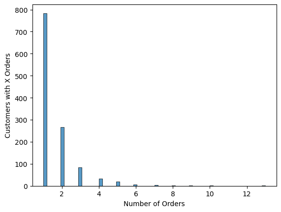

```python
# Get value_counts of customer_id to get the number of times a customer made an order
# X is the no. of orders, Y is the number of customers who made that many orders
sns.histplot(df['customer_id'].value_counts()).set(xlabel="Number of Orders", ylabel="Customers with X Orders")
```

Most users only used the app once or twice (around 1050), but the remaining 150 users used it three times or more.

#### restaurant_name

Similar to customer_id, this is categorical and we'll focus on the value counts.

```python
print(f"There are {len(df['restaurant_name'].unique())} restaurants with orders.")
```

```
There are 178 restaurants with orders.
```

```
[Text(0.5, 0, 'Number of Orders'), Text(0, 0.5, 'Restaurants with X Orders')]
```

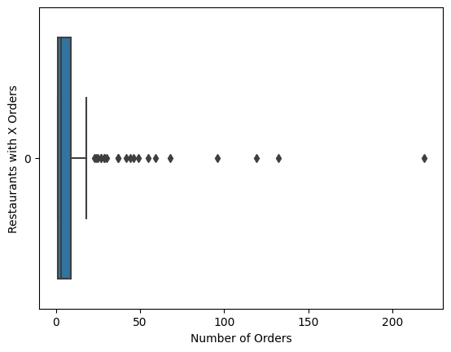

```python
sns.boxplot(df['restaurant_name'].value_counts(), orient='h').set(xlabel="Number of Orders", ylabel="Restaurants with X Orders")
```

Most restaurants only have a few orders, but the outliers have so many repeat orders that it's making the graph difficult to read. Let's try another look without them.

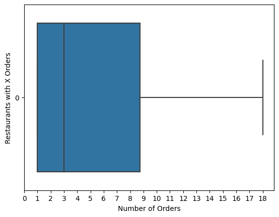

```python
sns.boxplot(df['restaurant_name'].value_counts(), orient='h', showfliers=False
).set(xlabel="Number of Orders", ylabel="Restaurants with X Orders", xticks=np.arange(0,19,1))
plt.show()
```

Even with the outliers removed, the boxplot still shows a right-skewed distribution, with ~50% of restaurants only being ordered from 3 times or fewer. At least 25% of all restuarants were only used once.